# Tarea 1

Marái José Meisel - Juan Pablo Dulcey

15/11/2021

# Incendios en Idaho

Cree un nuevo dataframe que sea un subconjunto del dataframe original de dfFires. El subconjunto debe contener todos los incendios del Estado de Idaho y las columnas deben ser limitadas para que sólo estén presentes las columnas YEAR_, CAUSE y TOTALACRES. Cambie el nombre de las columnas. Agrupe los datos por CAUSE y YEAR_ y luego resuma por el total de acres quemados. Trazar los resultado

## Descarga de base de datos

```r
df = read.table("RDataSets/StudyArea.csv", header=TRUE, fill=TRUE, quote="", sep=",")
names(df)
```

```
##  [1] "FID"        "ORGANIZATI" "UNIT"       "SUBUNIT"    "SUBUNIT2"
##  [6] "FIRENAME"   "CAUSE"      "YEAR_"      "STARTDATED" "CONTRDATED"
## [11] "OUTDATED"   "STATE"      "STATE_FIPS" "TOTALACRES"
```

## Flitramos la base de datos por Idaho y reducimos las variables a 3

```r
dfFires <- filter(df, STATE %in% c("Idaho"))
dfFires <- select(dfFires, YEAR_, CAUSE, TOTALACRES)
```

## Cambiamos el nombre de las columnas

```r
dfFires <- rename(dfFires, Año=YEAR_ , Causa=CAUSE , Acres_Quemados=TOTALACRES)
head(dfFires)
```

```
##    Año   Causa Acres_Quemados
## 1 1987   Human              5
## 2 1991 Natural            150
## 3 1991   Human            800
## 4 1990 Natural              2
## 5 1985   Human             38
## 6 1988   Human              2
```

## Detalles de los objetos

```r
str(dfFires)
```

```
## 'data.frame':    36014 obs. of  3 variables:
##  $ Año           : chr  "1987" "1991" "1991" "1990" ...
##  $ Causa         : chr  "Human" "Natural" "Human" "Natural" ...
##  $ Acres_Quemados: num  5 150 800 2 38 2 0.2 150 15 30 ...
```

## Comprobamos si existen vacios en Idaho.

```r
sum(with(dfFires,Causa == " "))
```

```
## [1] 43
```

En fecto hay 43 datos, como no están determinados se sumaran a los “Unfetermined”

```r
dfFires$Causa[dfFires$Causa == " "] <- "Undetermined"
```

## Realizamos un descriptivo

```r
summary(dfFires)
```

```
##      Año               Causa           Acres_Quemados
##  Length:36014       Length:36014       Min.   :     0.0
##  Class :character   Class :character   1st Qu.:     0.1
##  Mode  :character   Mode  :character   Median :     0.2
##                                        Mean   :   481.3
##                                        3rd Qu.:     2.0
##                                        Max.   :590620.0
```

## Agrupamos los datos en “Décadas”

```r
dfFires <- mutate(dfFires, Decada = ifelse(Año %in% 1980:1989, "1980-1989",
                                    ifelse(Año %in% 1990:1999, "1990-1999",
                                    ifelse(Año %in% 2000:2009, "2000-2009",
                                    ifelse(Año %in% 2010:2016, "2010-2016", "-99")))))
knitr::kable(head(dfFires))
```

| Año | Causa | Acres_Quemados | Decada |
| --- | --- | --- | --- |
| 1987 | Human | 5 | 1980-1989 |
| 1991 | Natural | 150 | 1990-1999 |
| 1991 | Human | 800 | 1990-1999 |
| 1990 | Natural | 2 | 1990-1999 |
| 1985 | Human | 38 | 1980-1989 |
| 1988 | Human | 2 | 1980-1989 |

```r
grp = group_by(dfFires, Decada, Causa)
sm = summarize(grp, mean(Acres_Quemados))
sm <- rename(sm, Decada=Decada , Causa=Causa , Acres_Quemados="mean(Acres_Quemados)")
```

## VIsualización gráfico

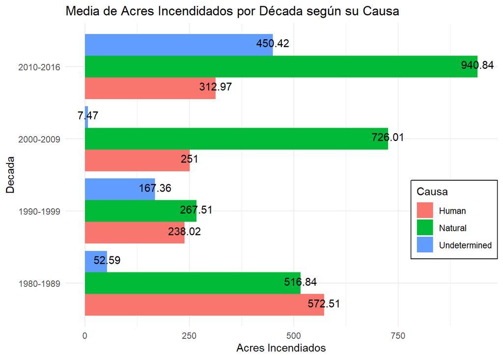

```r
ggplot(data=sm,aes(x=Decada, y=Acres_Quemados,fill=
Causa))+ theme_minimal() +
 geom_bar(stat='identity', position='dodge') +
  geom_text(aes(label=round(Acres_Quemados,2)), position=position_dodge(width=0.9), vjust=0.25) +
 coord_flip() +  scale_y_continuous(name="Acres Incendiados", labels = comma) +
  ggtitle ("Media de Acres Incendidados por Década según su Causa") +
    theme(
    legend.position = c(1, 1),
    legend.justification = c(1, 3),
    legend.background = element_rect(fill = "white", colour = "black"),
    plot.title = element_text(
      size = rel(1.2), lineheight = .9
    ))
```

# Atletas

```r
athe <- athe %>%
  filter(!is.na(Medal)) %>% filter( !is.na(Sex)) %>% filter( !is.na(Age)) %>%
    filter(!is.na(Height)) %>% filter(!is.na(Weight)) %>% filter(!is.na(Team)) %>%
    filter(!is.na(NOC)) %>% filter(!is.na(Year)) %>% filter(!is.na(Season)) %>%
    filter(!is.na(Sport))
```

### Filtra el DataFrame para incluir solo las filas correspondientes a los ganadores de medallas de 2016.

```r
athe<- athe %>% filter(Year == 2016)
```

### Descubre las medallas concedidas en 2016 en cada deporte

```r
sort(table(athe$Sport), decreasing = TRUE)
```

```
##
##              Swimming             Athletics                Rowing
##                   190                   188                   144
##              Football                Hockey              Handball
##                   105                    99                    89
##               Cycling              Canoeing            Water Polo
##                    84                    82                    78
##          Rugby Sevens            Basketball            Volleyball
##                    74                    72                    72
##             Wrestling            Gymnastics               Fencing
##                    72                    66                    65
##                  Judo                Boxing         Equestrianism
##                    56                    51                    45
##               Sailing              Shooting         Weightlifting
##                    45                    45                    45
##                Diving Synchronized Swimming             Taekwondo
##                    36                    32                    32
##               Archery          Table Tennis                Tennis
##                    24                    24                    24
##             Badminton   Rhythmic Gymnastics      Beach Volleyball
##                    23                    18                    12
##     Modern Pentathlon          Trampolining             Triathlon
##                     6                     6                     6
##                  Golf
##                     4
```

### Enumera los cinco deportes más importantes en función del mayor número de medallas concedidas. Filtra el DataFrame una vez más para incluir solo los registros de los cinco deportes principales en 2016.

```r
atdeport5 <- athe %>%
    filter(Sport %in% c("Swimming" , "Athletics",  "Rowing", "Football", "Hockey"))
```

```r
table(atdeport5$Medal,atdeport5$Sport)
```

```
##
##          Athletics Football Hockey Rowing Swimming
##   Bronze        61       35     33     48       57
##   Gold          65       35     34     48       70
##   Silver        62       35     32     48       63
```

```r
Principal_sports = data.frame(table(atdeport5$Medal,atdeport5$Sport))
Principal_sports <- rename(Principal_sports, Medal=Var1 , Sports=Var2 ,
Quantity=Freq)
head(Principal_sports)
```

```
##    Medal    Sports Quantity
## 1 Bronze Athletics       61
## 2   Gold Athletics       65
## 3 Silver Athletics       62
## 4 Bronze  Football       35
## 5   Gold  Football       35
## 6 Silver  Football       35
```

### Genere un gráfico de barras con los recuentos de registros correspondientes a cada uno de los cinco deportes principales.

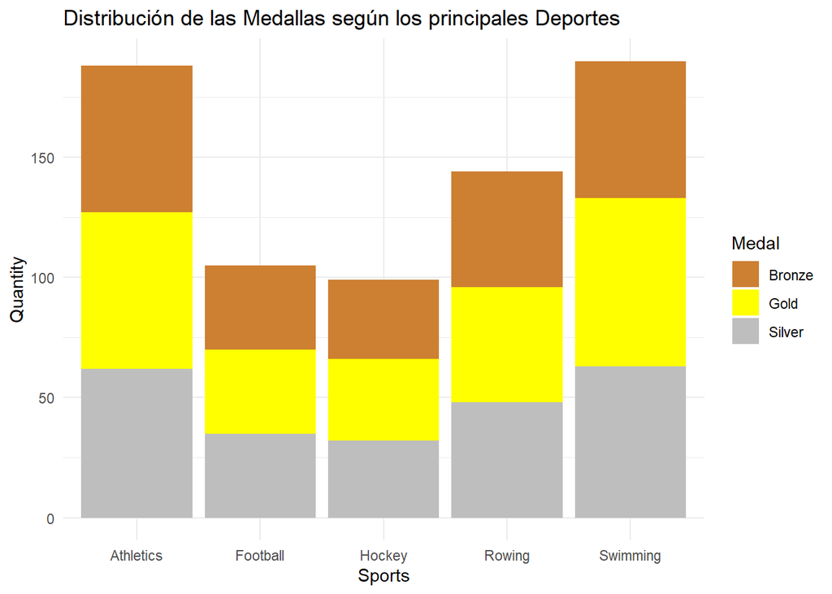

```r
ggplot(data=Principal_sports, aes(x=Sports, y=Quantity, fill=Medal)) +
    geom_bar(stat="identity") +
    scale_fill_manual(values=c("#cd7f32", "yellow","gray"))+ theme_minimal() +
  ggtitle ("Distribución de las Medallas según los principales Deportes")
```

### Generar un histograma para la característica Edad de todos los ganadores de medallas en los cinco deportes principales (2016).

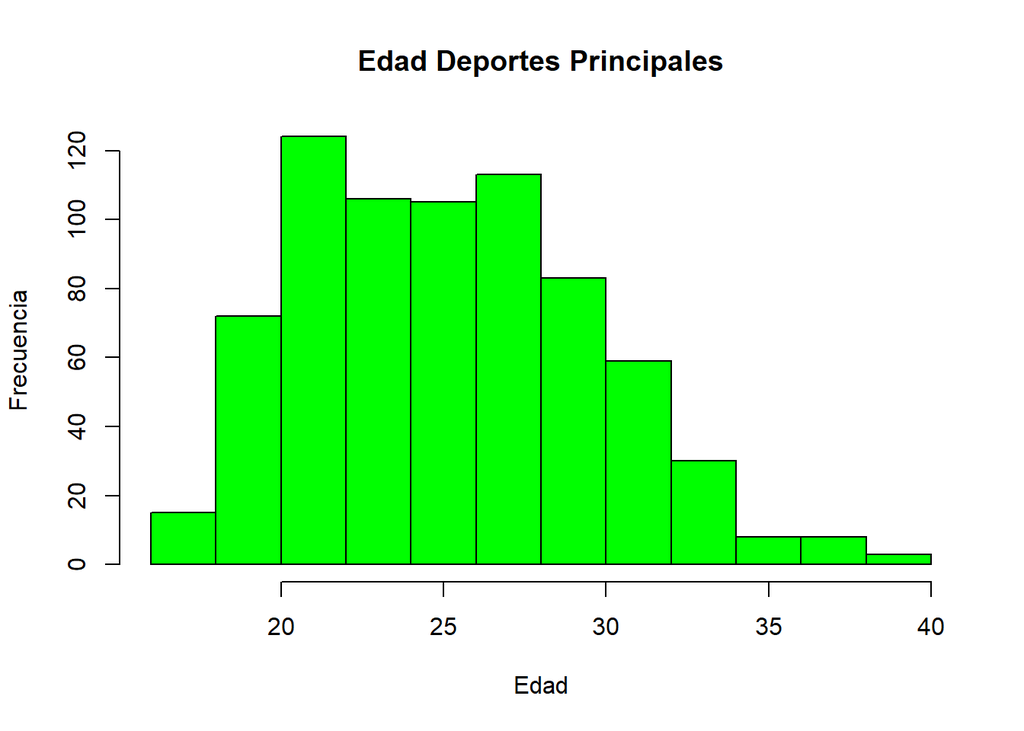

### Genera un gráfico de barras que indique cuántas medallas ganó el equipo de cada país en los cinco deportes principales en 2016.

```r
Principal_sports2 = data.frame(table(atdeport5$Medal,atdeport5$Sport, atdeport5$Team))
Principal_sports2 <- rename(Principal_sports2, Medal=Var1 , Sports=Var2 ,
Quantity=Freq, Country = Var3 )
head(Principal_sports2)
```

```
##    Medal    Sports Country Quantity
## 1 Bronze Athletics Algeria        0
## 2   Gold Athletics Algeria        0
## 3 Silver Athletics Algeria        2
## 4 Bronze  Football Algeria        0
## 5   Gold  Football Algeria        0
## 6 Silver  Football Algeria        0
```

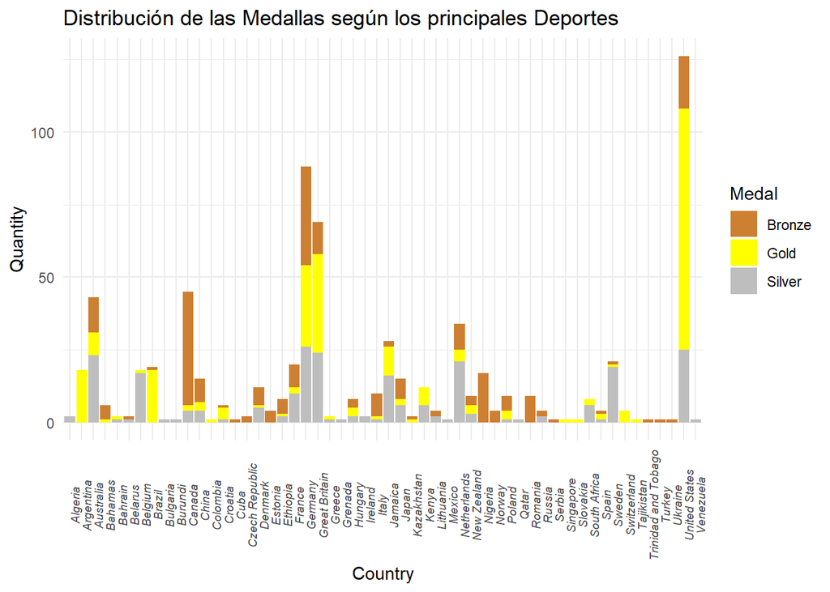

```r
ggplot(data=Principal_sports2, aes(x=Country, y=Quantity, fill=Medal)) +
    geom_bar(stat="identity") +
    scale_fill_manual(values=c("#cd7f32", "yellow","gray"))+ theme_minimal() +
  ggtitle ("Distribución de las Medallas según los principales Deportes") +
    theme (axis.text.x = element_text(face="italic", size=rel(0.8), angle = 90))
```

### Genere un gráfico de barras que indique el peso medio de los jugadores, clasificados en función del género, que ganaron en los cinco principales deportes en 2016.

```r
library(plyr)
sexmed<-ddply(atdeport5,.(Sex), summarize, mean=mean(Weight))
```

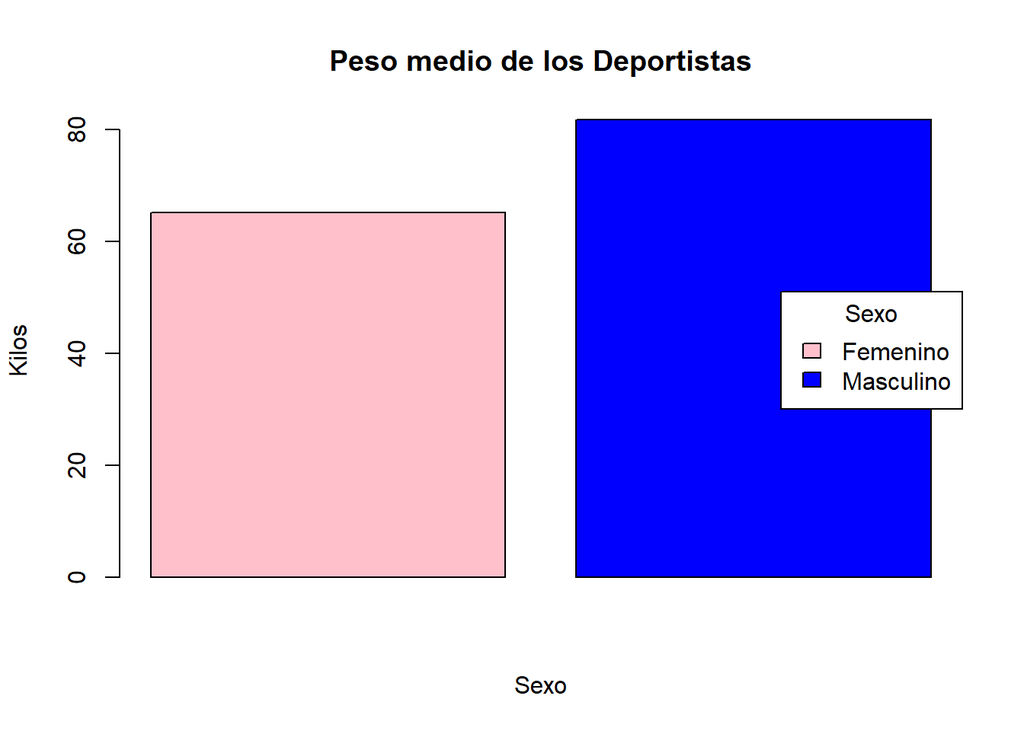

```r
barplot(sexmed$mean, axes=TRUE,axisname=TRUE,
        col=c('pink', 'blue'),main="Peso medio de los Deportistas",
        xlab="Sexo", ylab="Kilos")
legend(x = "right", legend = c("Femenino", "Masculino"), fill = c("pink", "blue"),
       title = "Sexo")
```